# ML_final_project

## Start DESeq workflow

### Create the DESeq object

```r
dds_earli_groups <- DESeqDataSetFromMatrix(countData = df_counts_30plus,
                                           colData = df_metadata_filtered_g124,
                                           design = ~ Group)
```

#### Rewrite plotPCA function to plot PCAs 3 and 4

```r
#* rewrite the plotPCA function to plot the 3rd and 4th PCs
plotPCA34 <- function (object, intgroup = "condition", ntop = 500, returnData = FALSE)
{
    rv <- rowVars(assay(object))
    select <- order(rv, decreasing = TRUE)[seq_len(min(ntop,
                                                       length(rv)))]
    pca <- prcomp(t(assay(object)[select, ]))
    percentVar <- pca$sdev^2/sum(pca$sdev^2)
    if (!all(intgroup %in% names(colData(object)))) {
        stop("the argument 'intgroup' should specify columns of colData(dds)")
    }
    intgroup.df <- as.data.frame(colData(object)[, intgroup,
                                                 drop = FALSE])
    group <- if (length(intgroup) > 1) {
        factor(apply(intgroup.df, 1, paste, collapse = ":"))
    } else {
        colData(object)[[intgroup]]
    }

    d <- data.frame(PC3 = pca$x[, 3], PC4 = pca$x[, 4], group = group,
                    intgroup.df, name = colnames(object))

    if (returnData) {
        attr(d, "percentVar") <- percentVar[3:4]
        return(d)
    }

    ggplot(data = d, aes_string(x = "PC3", y = "PC4",color = "group")) +
        geom_point(size = 3) +
        xlab(paste0("PC3: ", round(percentVar[3] * 100), "% variance")) +
        ylab(paste0("PC4: ", round(percentVar[4] * 100), "% variance")) +
        coord_fixed()
}
```

### Quality assessment metrics

```r
# normalize the raw counts
dds_earli_groups <- estimateSizeFactors(dds_earli_groups)

# log transform the data
vst_earli_groups <- vst(dds_earli_groups, blind = TRUE)
vst_matrix <- assay(vst_earli_groups)
vst_correlations <- cor(vst_matrix)
```

#### Generate the heatmap to assess for outliers

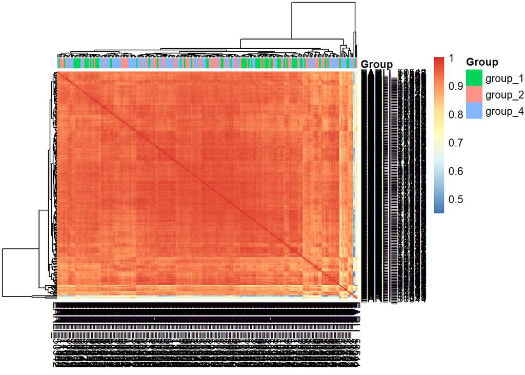

```r
pheatmap(vst_correlations,
         annotation_col = df_metadata_filtered_g124[,"Group", drop = FALSE])
```

Significant outliers on the heatmap: EARLI_11997, EARLI_11329, EARLI_50514, EARLI_11417. which are noted by the significantly different variances from the normalized counts created in the `vst_correlations` object.

#### Perform PCA to assess for outliers

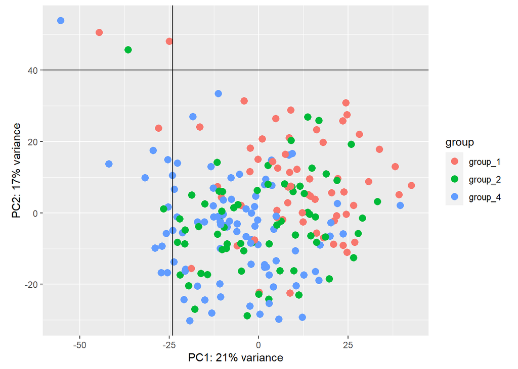

```r
plotPCA(vst_earli_groups, intgroup = "Group", ntop = 1000)+
   geom_vline(xintercept = -24) + geom_hline(yintercept = 40)
```

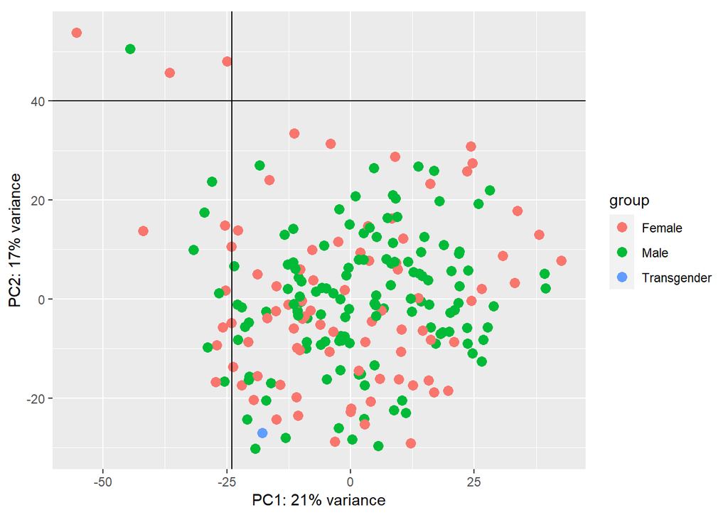

```r
plotPCA(vst_earli_groups, intgroup = "Gender", ntop = 1000)+
   geom_vline(xintercept = -24) + geom_hline(yintercept = 40)
```

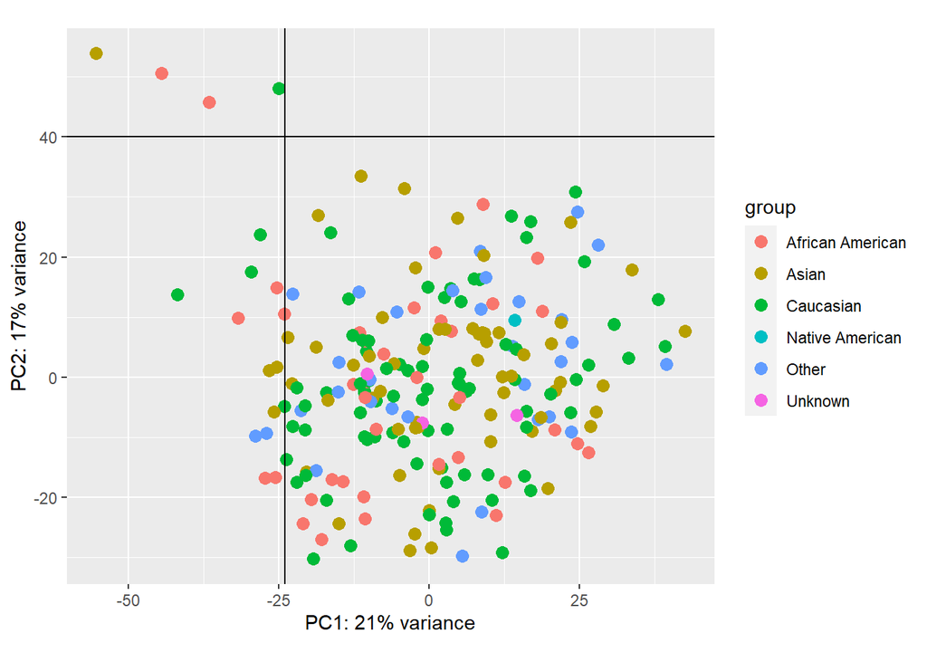

```r
plotPCA(vst_earli_groups, intgroup = "Race", ntop = 1000)+
   geom_vline(xintercept = -24) + geom_hline(yintercept = 40)
```

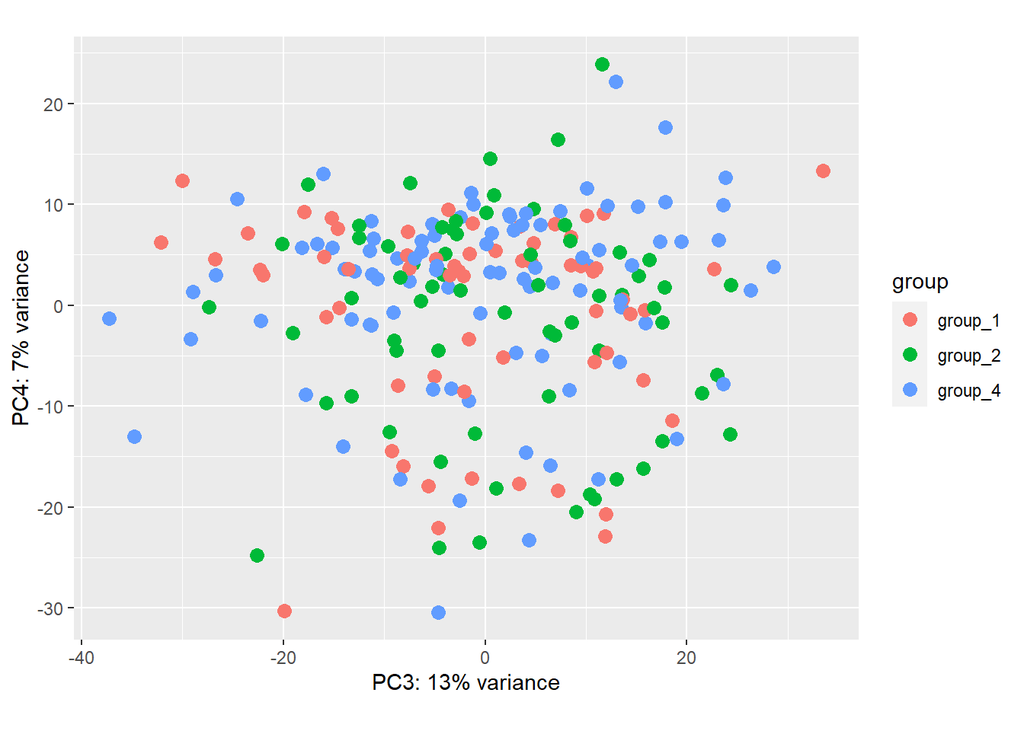

```r
plotPCA34(vst_earli_groups, intgroup = "Group", ntop = 1000)
```

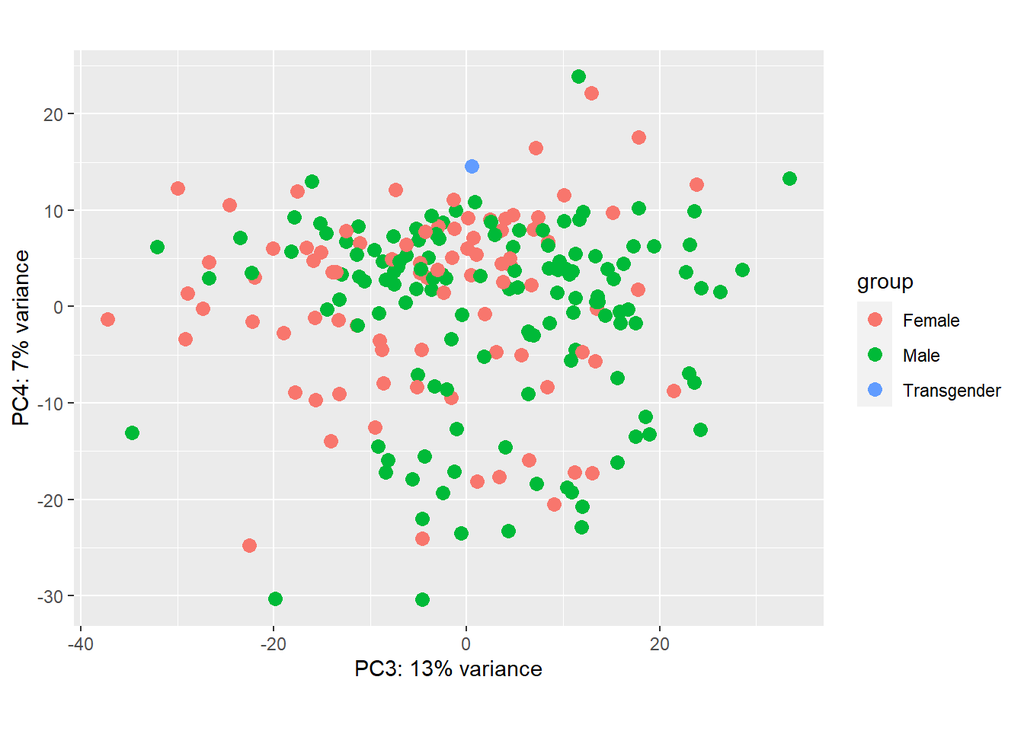

```r
plotPCA34(vst_earli_groups, intgroup = "Gender", ntop = 1000)
```

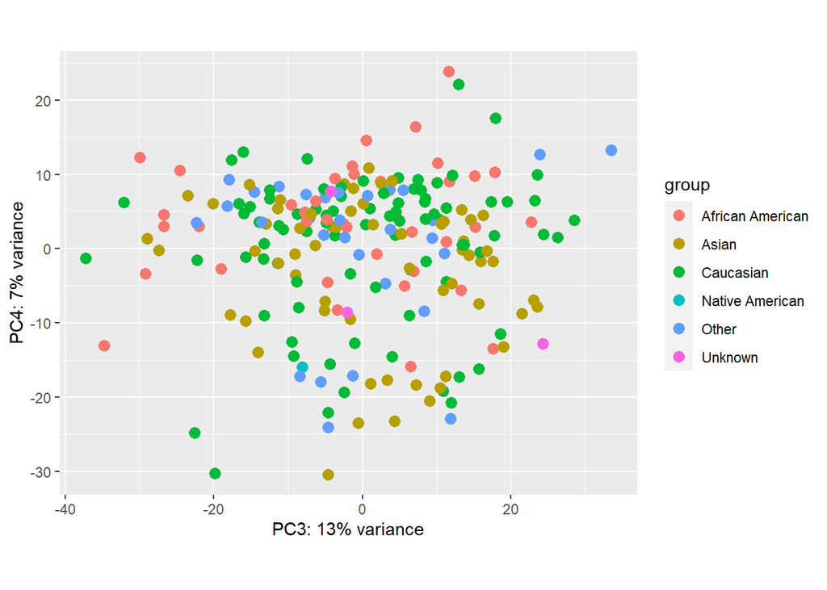

```r
plotPCA34(vst_earli_groups, intgroup = "Race", ntop = 1000)
```

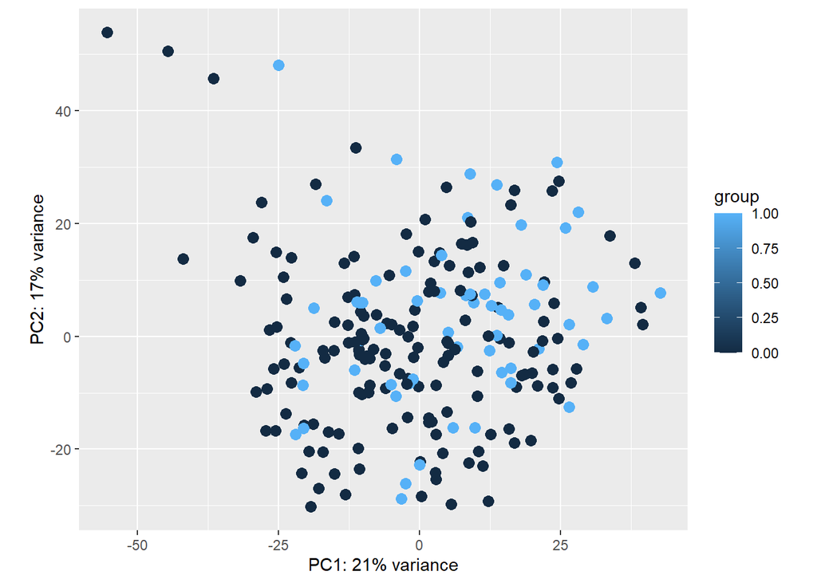

```r
# plot other possible explanatory variables
plotPCA(vst_earli_groups, intgroup="PtSepsis", ntop=1000)
```

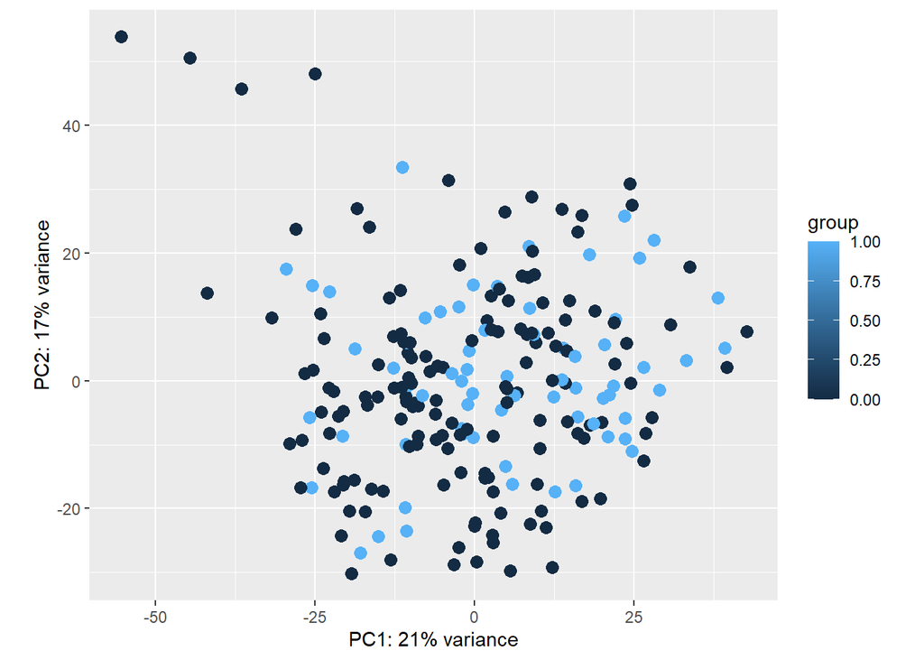

```r
plotPCA(vst_earli_groups, intgroup="28d death", ntop=1000)
```

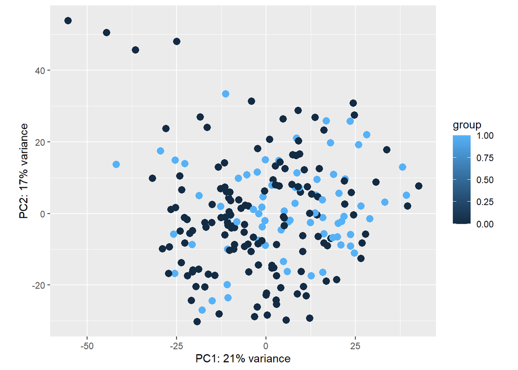

```r
plotPCA(vst_earli_groups, intgroup="60d death", ntop=1000)
```

The PCA plots are used to assess whether major explanatory variables are associated with separation by the most significantly explanatory principle components. There are four outlying points noted in the plots above that are likely outliers. These need to be identified and compared to those outlying points in the heatmap above.

### Perform manual PCA

```r
# get the PCA object for plotting
row_variance <- rowVars(vst_matrix)
select_idx <- order(row_variance, decreasing = TRUE)[1:1000]
transposed_selected_vst_matrix <- t(vst_matrix[select_idx,])
pca_values <- prcomp(transposed_selected_vst_matrix)

# get the percentage of variance explained by each PC
percent_var_explained <- pca_values$sdev^2/sum((pca_values$sdev)^2)

# minimum number of PCs explaining 80% of the variance
(minPCs <- min(which(cumsum(percent_var_explained) > 0.8)))
```

```
## [1] 15
```

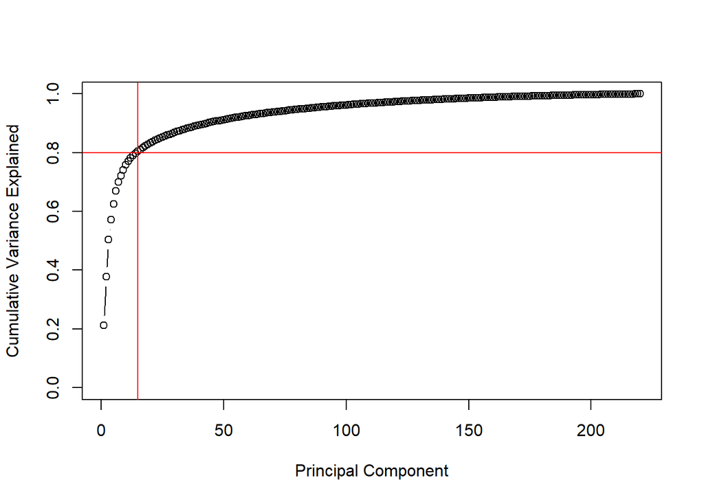

```r
# plot cumulative variance explained
plot(1:length(percent_var_explained),
     cumsum(percent_var_explained),
     xlab="Principal Component",
     ylab="Cumulative Variance Explained", ylim=c(0,1), type='b')
abline(h=0.8, col="red")
abline(v=15, col="red")
```

#### Find the outliers in the PCA analysis

```r
# which EARLI_{barcode}s have PC1 < -24 and PC2 > 40?
pca1andpca2 <- pca_values$x[,1:2]
outliers_idx <- which(pca1andpca2[,1] < -24 & pca1andpca2[,2] > 40)
pca1andpca2[outliers_idx,]
```

```
##                   PC1      PC2
## EARLI_11329 -44.54455 50.53825
## EARLI_11417 -24.97368 48.02750
## EARLI_50514 -36.53306 45.69447
## EARLI_11997 -55.35811 53.87412
```

These outliers in the PCA are also outliers in the heatmap.

| EARLI_barcode | PC1 | PC2 |
| --- | --- | --- |
| EARLI_11329 | -44.54455 | 50.53825 |
| EARLI_11417 | -24.97368 | 48.02750 |
| EARLI_50514 | -36.53306 | 45.69447 |
| EARLI_11997 | -55.35811 | 53.87412 |

#### Remove the identified outliers

```r
# pull the names of the outliers
names_outliers <- rownames(pca1andpca2[outliers_idx,])

# remove outliers prior to starting the final DE analysis
df_counts_30plus_noOutliers <-
    df_counts_30plus[!(colnames(df_counts_30plus) %in% names_outliers)]
df_metadata_filtered_g124_noOutliers <-
    df_metadata_filtered_g124[!(rownames(df_metadata_filtered_g124) %in% names_outliers),]

# remove unnecessary objects from global environment
rm("vst_correlations","vst_earli_groups","vst_matrix","select_idx",
"transposed_selected_vst_matrix","row_variance","pca1andpca2",
"percent_var_explained","plotPCA34","names_outliers","outliers_idx",
"p1","p2","p3","p4","p5","p6","pca_values","dds_earli_groups","df_counts_30plus",
"df_metadata_filtered", "df_metadata_filtered_g124", "minPCs")
```

## DESeq analysis with outliers removed

```r
# recreate the DESeq object
dds_earli_groups_noOutliers <-
    DESeqDataSetFromMatrix(countData = df_counts_30plus_noOutliers,
                           colData = df_metadata_filtered_g124_noOutliers,
                           design = ~ Group)

# perform the DESeq analysis
dds_earli_groups_noOutliers <- DESeq(dds_earli_groups_noOutliers)
```

```
## -- replacing outliers and refitting for 194 genes
## -- DESeq argument 'minReplicatesForReplace' = 7
## -- original counts are preserved in counts(dds)
```

### Model diagnostics

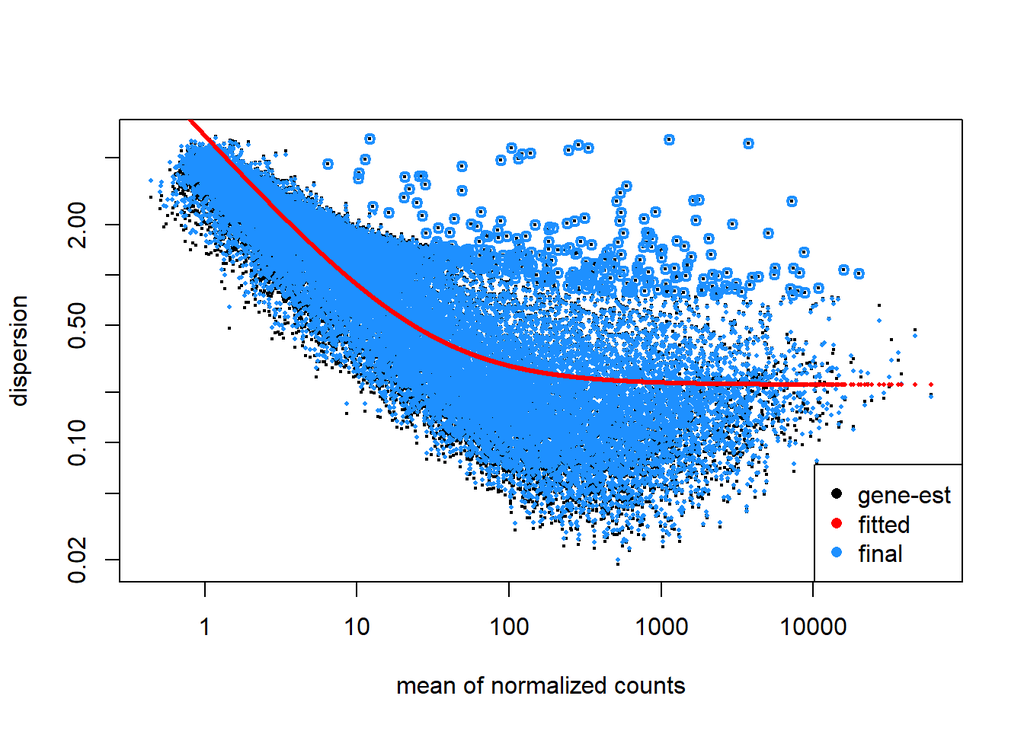

```r
# plot the dispersion estimates to assess quality of the analysis
plotDispEsts(dds_earli_groups_noOutliers)
```

The dispersion should decrease consistently as the mean of the normalized counts increases. The plot above shows an appropriate plot that means the data pass this diagnostic step and the analysis can continue as planned.

## Group 1 (Bacteremic sepsis) vs. group 4 (no sepsis) analysis

```r
# extract group 1 vs. group 4 results
earli_groups14_results <- results(dds_earli_groups_noOutliers,
                                  name = "Group_group_4_vs_group_1",
                                  alpha = 0.05)
```

### More model diagnostics

#### MA-plot (intensity ratio by average intensity)

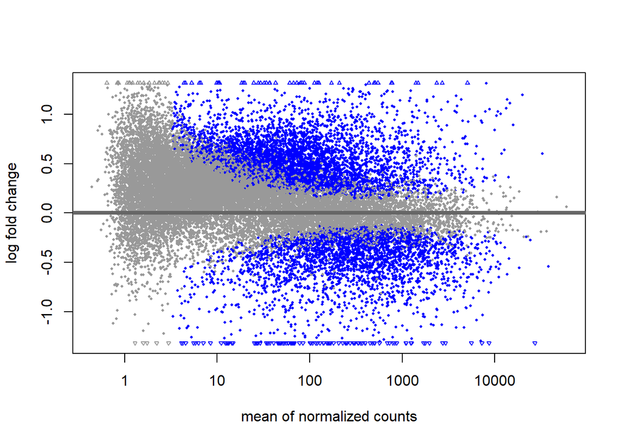

```r
#* MA plot without LFC shrinkage
plotMA(earli_groups14_results)
```

$\log_2$ fold changes of those genes with very low normalized gene counts are shrunken to remove the noise inherent in such low gene count data. The MA-plot is the reproduced to assess these changes.

```r
#* perform the LFC shrinkage
earli_groups14_results <- lfcShrink(dds = dds_earli_groups_noOutliers,
                                    coef = "Group_group_4_vs_group_1",
                                    res = earli_groups14_results)
```

```
## using 'apeglm' for LFC shrinkage. If used in published research, please cite:
##     Zhu, A., Ibrahim, J.G., Love, M.I. (2018) Heavy-tailed prior distributions for
##     sequence count data: removing the noise and preserving large differences.
##     Bioinformatics. https://doi.org/10.1093/bioinformatics/bty895
```

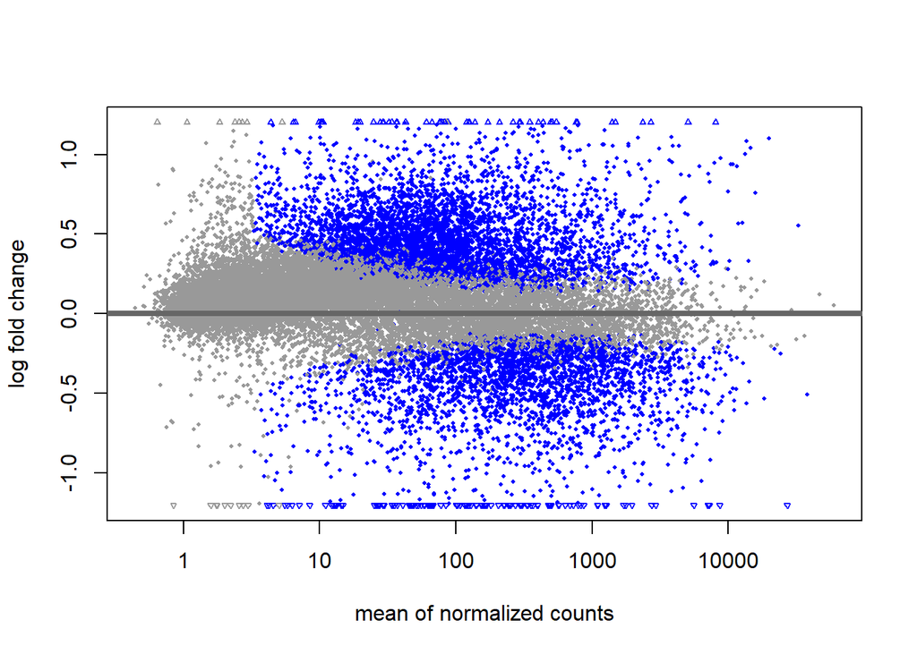

```r
#* MA plot after LFC shrinkage
plotMA(earli_groups14_results)
```

#### p value histogram

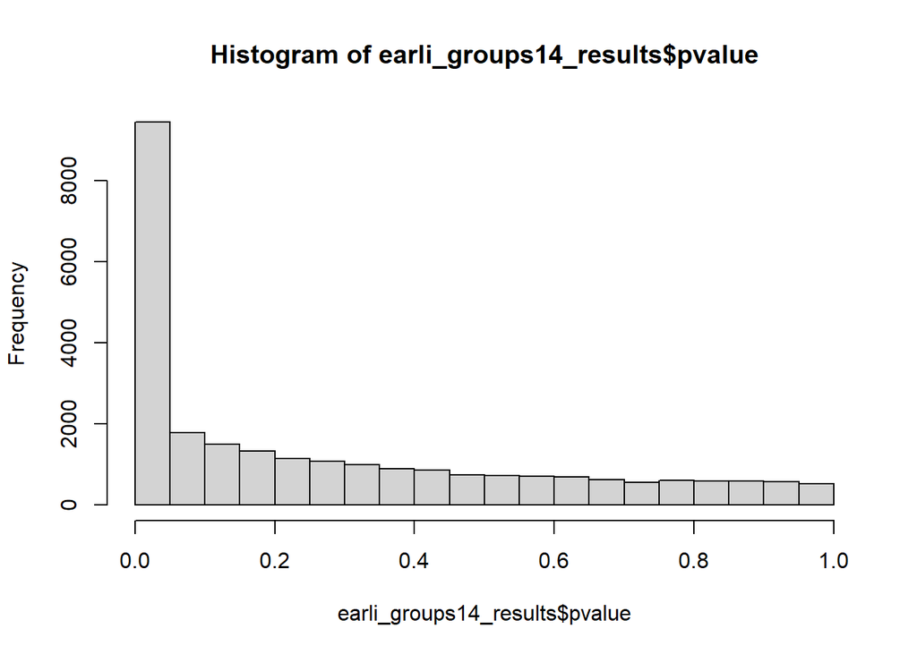

```r
#* plot a histogram of the p values
hist(earli_groups14_results$pvalue)
```

The large $p$ values should be uniformly distributed while the low $p$ values should increase sharply. This is another model diagnostic that passes in this case.

### Summary of results

```r
summary(earli_groups14_results)
```

```
##
## out of 25953 with nonzero total read count
## adjusted p-value < 0.05
## LFC > 0 (up)       : 4491, 17%
## LFC < 0 (down)     : 2995, 12%
## outliers [1]       : 0, 0%
## low counts [2]     : 5032, 19%
## (mean count < 3)
## [1] see 'cooksCutoff' argument of ?results
## [2] see 'independentFiltering' argument of ?results
```

## Generate heatmap figures

### Filter for genes with a p value < 0.05

```r
# turn the results into a data.table
dt_earli_groups14_results <- data.table(data.frame(earli_groups14_results),
                                         keep.rownames = TRUE)

# change the name of the "rn" row
setnames(dt_earli_groups14_results, old="rn",new="ensg_name")

# order by padj
setorder(dt_earli_groups14_results, padj)

# remove the NA values from the data.table
dt_earli_groups14_results_noNA <- dt_earli_groups14_results[!is.na(padj)]

# save only those adjusted p values < 0.05
dt_earli_groups14_results_noNA_sigP <- dt_earli_groups14_results_noNA[padj < 0.05]
```

### Get normalized count values only in the significantly DE genes

```r
# filter for genes pval <0.05
normalized_counts_sig <- counts(dds_earli_groups_noOutliers, normalized = TRUE)

# filter all normalized counts using ranked and significant g14 data
normalized_counts_sig <- normalized_counts_sig[dt_earli_groups14_results_noNA_sigP$ensg_name,]

# get normalized_counts for only groups 1 and 4
group14_idx <-
    which(df_metadata_filtered_g124_noOutliers$Group %in% c("group_1", "group_4"))

# filter the data.frame with the index
df_metadata_filtered_g14 <- df_metadata_filtered_g124_noOutliers[group14_idx,]

# drop the empty factor levels
df_metadata_filtered_g14$Group <- droplevels(df_metadata_filtered_g14$Group)

# get the rownames, which can filter the counts matrix
to_keep_14 <- rownames(df_metadata_filtered_g14)

# filter the normalized counts matrix for only groups 1, 4
normalized_counts_sig14 <- normalized_counts_sig[,to_keep_14]
```

### Perform vst transformation

```r
# get VST transformed counts
vst_counts <- varianceStabilizingTransformation(dds_earli_groups_noOutliers)
vst_counts_mat <- assay(vst_counts)

# vst_counts_mat has the same exact structure as the normalized_counts_sig matrix above. The same process will be used to generate the vst matrix to create the heat maps below
vst_counts_mat_sig <- vst_counts_mat[dt_earli_groups14_results_noNA_sigP$ensg_name,]
vst_counts_mat_sig14 <- vst_counts_mat_sig[,to_keep_14]
```

### Generate the heatmaps

#### All differentially expressed genes

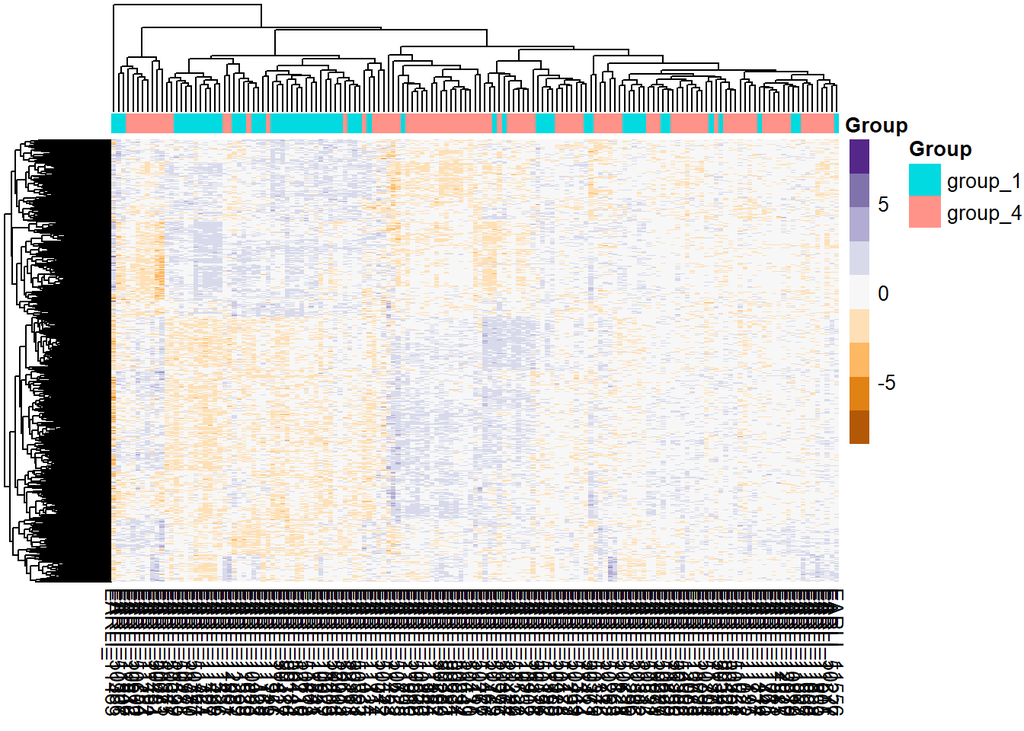

```r
# brew the colors
heat_colors <- brewer.pal(9, "PuOr")

# all vst counts for groups 1 and 4; no top DE genes filtered
pheatmap(vst_counts_mat_sig14,
         color=heat_colors,
         show_rownames = FALSE,
         cluster_rows=TRUE,
         annotation_col=df_metadata_filtered_g14[, c("Group"), drop=FALSE],
         scale="row")
```

#### Top 1000 differentially expressed genes

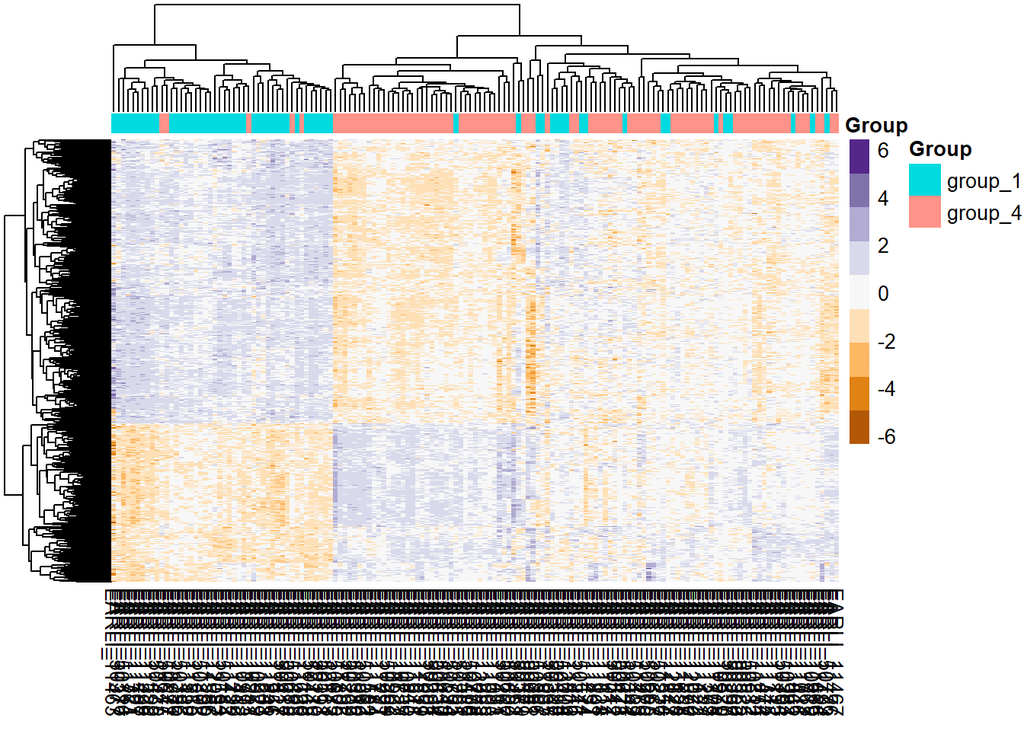

```r
# get the top 1000 DE genes from the results
dt_earli_groups14_results_noNA_sigP_top1000 <-
    dt_earli_groups14_results_noNA_sigP[1:1000,]

# get top 1000 for vst normalized counts
vst_counts_mat_sig14_top1000 <-
    vst_counts_mat_sig14[dt_earli_groups14_results_noNA_sigP_top1000$ensg_name,]

pheatmap(vst_counts_mat_sig14_top1000,
         color=heat_colors,
         show_rownames=FALSE,
         cluster_rows=TRUE,
         annotation_col=df_metadata_filtered_g14[, c("Group"), drop=FALSE],
         scale="row")
```

#### Top 500 differentially expressed genes

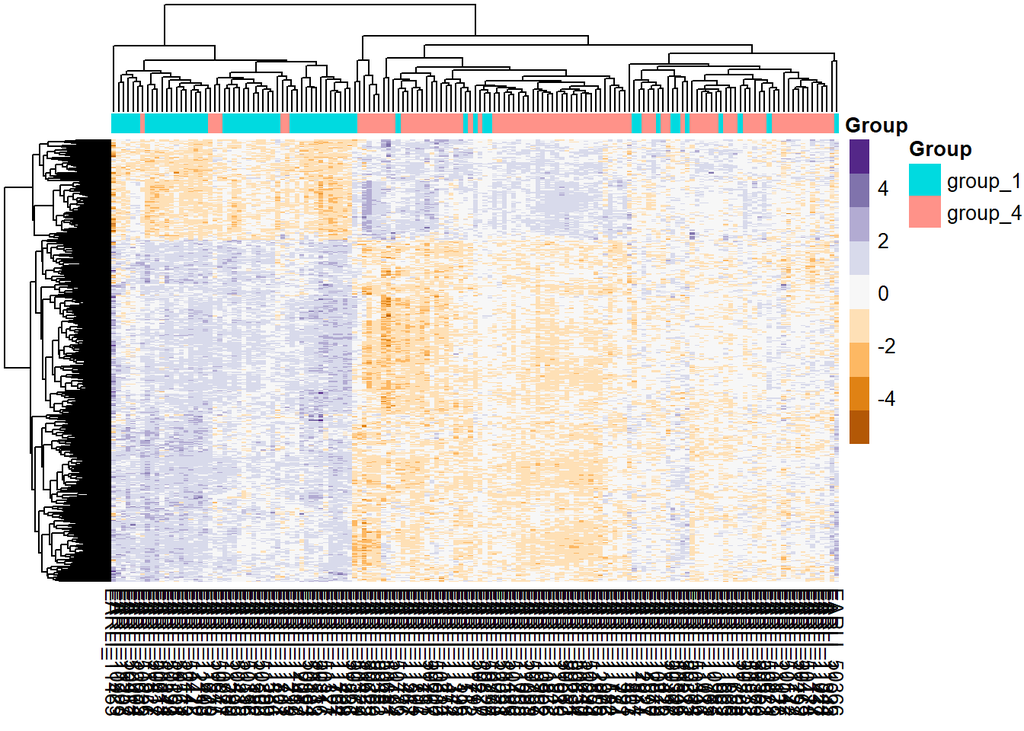

```r
# get the top 500 DE genes from the results
dt_earli_groups14_results_noNA_sigP_top500 <-
    dt_earli_groups14_results_noNA_sigP[1:500,]

# get top 500 for vst normalized counts
vst_counts_mat_sig14_top500 <-
    vst_counts_mat_sig14[dt_earli_groups14_results_noNA_sigP_top500$ensg_name,]

pheatmap(vst_counts_mat_sig14_top500,
         color=heat_colors,
         show_rownames=FALSE,
         cluster_rows=TRUE,
         annotation_col=df_metadata_filtered_g14[, c("Group"), drop=FALSE],
         scale="row")
```

### Top 25 differentially expressed genes, boxplot

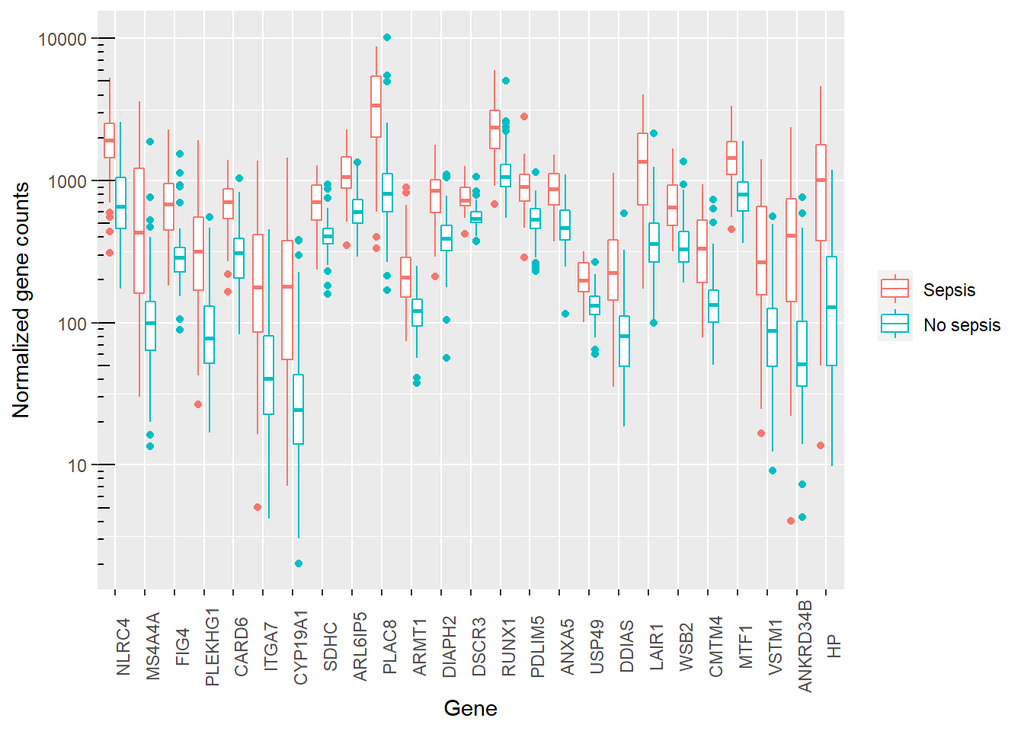

```r
# read in the gene symbols that assess function
gene_symbols <- fread("gene_attr.txt", header = FALSE)
setnames(gene_symbols,
         old=c("V1","V2","V3","V4"),
         new=c("ensg_name","V2","type","symbol"))

# get the top 25 genes based on padj
dt_earli_groups14_results_noNA_sigP_top25 <- dt_earli_groups14_results_noNA_sigP[1:25,]

# subset the normalized counts matrix using the ensg_name
normalized_counts_sig_top25 <-
    normalized_counts_sig[dt_earli_groups14_results_noNA_sigP_top25$ensg_name,]

# make it a data.table
dt_normalized_counts_sig_top25 <- data.table(normalized_counts_sig_top25,
                                             keep.rownames = TRUE)
# rename
setnames(dt_normalized_counts_sig_top25, old="rn", new="ensg_name")

# melt
dt_norm_cnt_sig_top25_melted <- melt(dt_normalized_counts_sig_top25,
                                     id.vars = "ensg_name",
                                     variable.name = "participant",
                                     value.name = "norm_counts")

# merge with the metadata
#* change the metadata into a data.table with only 2 columns
dt_metadata_forMerge <- data.table(df_metadata_filtered_g124_noOutliers,
                                   keep.rownames = TRUE)
setnames(dt_metadata_forMerge, old="rn", new = "participant")
dt_metadata_forMerge <- dt_metadata_forMerge[,c("participant", "Group")]

dt_for_plot <- merge(dt_norm_cnt_sig_top25_melted, dt_metadata_forMerge,
      by = "participant", all.x = TRUE)

dt_for_plot <- merge(dt_for_plot, gene_symbols[,c("ensg_name", "symbol")],
                     by="ensg_name", all.x=TRUE)

# make the plot
ggplot(dt_for_plot[Group %in% c("group_1","group_4")],
       aes(x=symbol,y=norm_counts,
           color=factor(Group,levels=c("group_1","group_4"),
                        labels=c("Sepsis","No sepsis"))))+ # relabel the legend
    geom_boxplot()+
    scale_y_log10()+
    annotation_logticks(sides = "l")+ # add logticks so log scale is obvious
    xlab("Gene")+
    ylab("Normalized gene counts")+
    theme(axis.text.x=element_text(angle=90))+ # angle the axis labels
    scale_x_discrete(limits=c(unique(dt_for_plot$symbol)))+ # order top 1-25
    guides(color=guide_legend(title=NULL)) # remove the legend title
```

## Webgestalt data preparation

```r
#* copy the results without NAs
web_gestalt_g14 <- copy(dt_earli_groups14_results_noNA)

# rank in order of logFC from highest to lowest
web_gestalt_g14_p0.1 <- web_gestalt_g14[padj <0.1]

# plug in two columns; first column is gene name, 2nd column in logFC
web_gestalt_g14_p0.1 <- merge(web_gestalt_g14_p0.1, gene_symbols, by="ensg_name", all.x=T)
web_gestalt_g14_p0.1[,`:=`(baseMean=NULL, lfcSE=NULL, pvalue=NULL, padj=NULL,
                      V2=NULL,ensg_name=NULL,type=NULL)]
setcolorder(web_gestalt_g14_p0.1,neworder = c("symbol", "log2FoldChange"))
setorder(web_gestalt_g14_p0.1, log2FoldChange)
write.table(web_gestalt_g14_p0.1, "webgestalt_g14.rnk", sep = "\t", row.names = F,
            col.names=F, quote=F)

# write the table to plug into webgestalt
write.table(web_gestalt_g14_p0.1,
            "webgestalt_g14_foldSwitch.rnk", sep = "\t", row.names = F,
            col.names=F, quote=F)
```